# Explorative data analysis for FINDONOR with women as one group- CHANGES IN SELF-RATED HEALTH DURING THE STUDY AND IT’S RELATION TO IRON BIOMARKERS

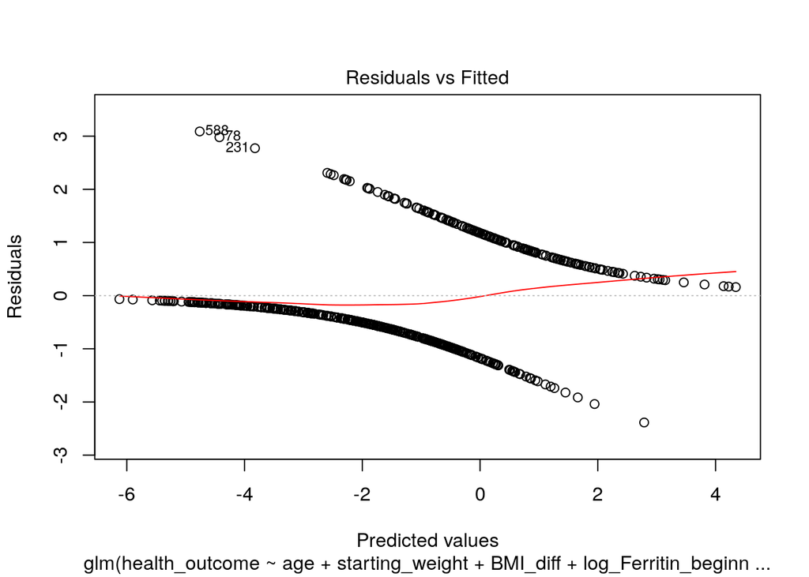

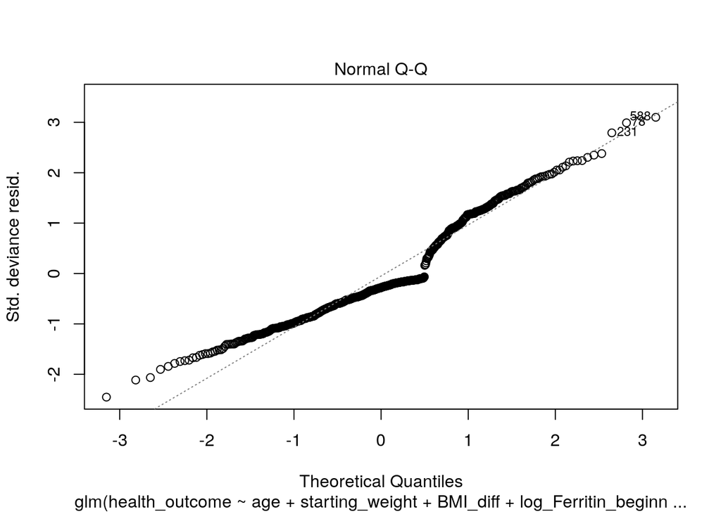

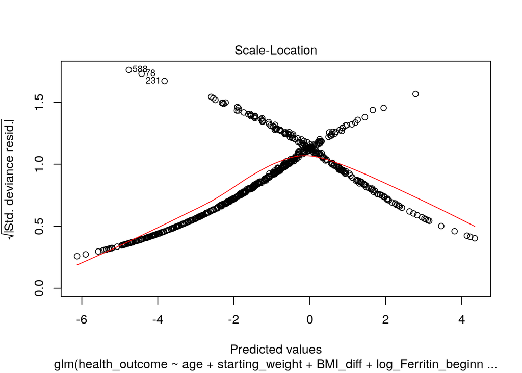

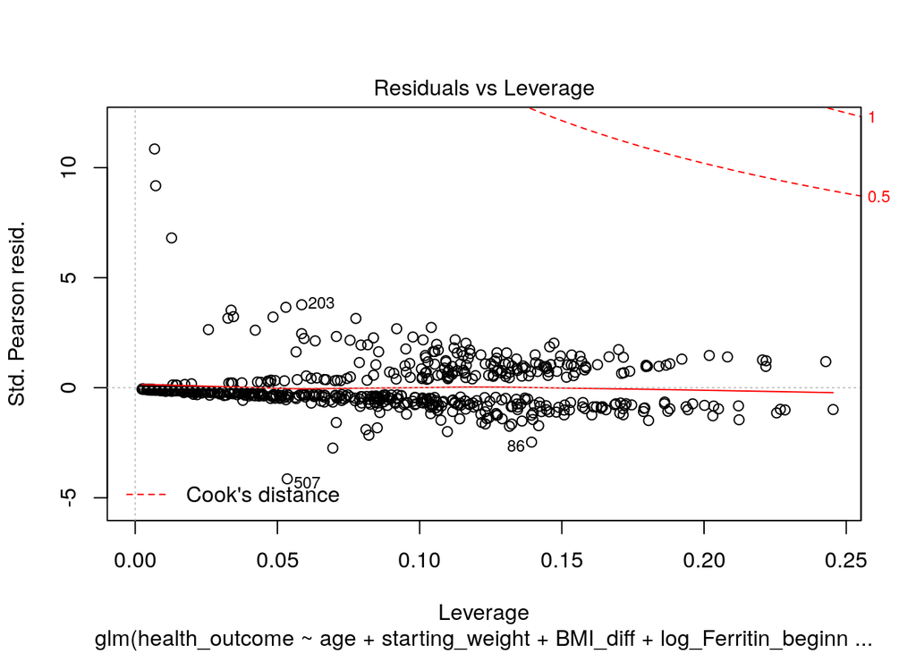

```r
plot(logit_women)
```

```r
vif(logit_women)
```

```
##                            GVIF Df GVIF^(1/(2*Df))
## age                    1.484523  1        1.218410
## starting_weight        1.318885  1        1.148427
## BMI_diff               1.285699  1        1.133887
## log_Ferritin_beginning 1.353416  1        1.163364
## Hb_beginning           1.303172  1        1.141566
## donation_frequency     1.238051  1        1.112677
## health_very_good       2.593073  1        1.610302
## health_excellent       2.913321  1        1.706845
## cholesterol_d          1.241022  1        1.114012
## blood_sugar_d          1.248099  1        1.117183
## HBP_d                  1.169779  1        1.081563
## low_hb_hist_d          1.157517  1        1.075880
## anemia_hist_d          1.190560  1        1.091128
## iron_supp_d            1.276338  2        1.062898
## freq_calm_d            1.374146  2        1.082700
## freq_red_meat_d        1.322189  2        1.072317
## freq_fruits_d          1.383896  2        1.084616
## freq_juices_d          1.264938  2        1.060516
## freq_wholem_d          1.321078  2        1.072092
## freq_milk_d            1.264631  2        1.060452
## freq_cof_d             1.356989  2        1.079305
## freq_tea_d             1.279064  2        1.063465
## phys_cond_d            1.379682  2        1.083789
## act_heavy_d            1.486055  2        1.104101
## sleep_enough_d         1.339166  2        1.075743
## day_act_d              1.300672  2        1.067928
## h_act_light_d          1.430042  2        1.093546
## vita_multi_d           1.339342  2        1.075778
## sleep_tired_d          1.286964  2        1.065103
## anti_inf_d             1.347396  2        1.077392
## phys_inf_d             1.511281  2        1.108757
## freq_alc_d             1.239286  2        1.055098
```

```r
logistic.display(logit_women,simplified=TRUE)
```

```
##
##                                  OR  lower95ci   upper95ci     Pr(>|Z|)
## age                       1.0393158  0.9447329   1.1433680 4.282864e-01
## starting_weight           1.1013290  1.0033289   1.2089012 4.237096e-02
## BMI_diff                  1.0082950  0.8832616   1.1510281 9.026673e-01
## log_Ferritin_beginning    0.9474047  0.7335300   1.2236387 6.789613e-01
## Hb_beginning              1.0510489  0.9027336   1.2237316 5.211929e-01
## donation_frequency        0.6953599  0.5401883   0.8951052 4.801045e-03
## health_very_good         12.7964787  6.3449796  25.8077845 1.062019e-12
## health_excellent         53.9856375 22.5873821 129.0299624 2.905679e-19
## cholesterol_dTRUE         3.0928281  1.4541850   6.5779706 3.362666e-03
## blood_sugar_dTRUE         1.8520951  0.5599894   6.1255743 3.125580e-01
## HBP_dTRUE                 0.7356911  0.2700450   2.0042638 5.483280e-01
## low_hb_hist_dTRUE         0.9859920  0.4930682   1.9716952 9.681746e-01
## anemia_hist_dTRUE         1.4034296  0.4524899   4.3528370 5.572996e-01
## iron_supp_dStable         1.4810803  0.6648339   3.2994692 3.365100e-01
## iron_supp_dIncreased      1.6115144  0.6568504   3.9536838 2.973717e-01
## freq_calm_dStable         0.5793761  0.3461864   0.9696416 3.777420e-02
## freq_calm_dIncreased      0.6061895  0.3105351   1.1833306 1.424514e-01
## freq_red_meat_dStable     1.0877458  0.6586937   1.7962688 7.424270e-01
## freq_red_meat_dIncreased  0.9723424  0.4814790   1.9636368 9.376587e-01
## freq_fruits_dStable       1.2923827  0.7361433   2.2689236 3.717526e-01
## freq_fruits_dIncreased    0.8875362  0.4394623   1.7924642 7.393806e-01
## freq_juices_dStable       1.0637715  0.6497494   1.7416099 8.058535e-01
## freq_juices_dIncreased    1.1526531  0.5787202   2.2957713 6.861189e-01
## freq_wholem_dStable       0.6608549  0.3757406   1.1623157 1.504779e-01
## freq_wholem_dIncreased    0.5374254  0.2781735   1.0382944 6.458498e-02
## freq_milk_dStable         0.8666937  0.5192501   1.4466208 5.841329e-01
## freq_milk_dIncreased      1.7370918  0.9297686   3.2454183 8.334163e-02
## freq_cof_dStable          0.6793741  0.3651244   1.2640872 2.223730e-01
## freq_cof_dIncreased       0.5077767  0.2190823   1.1768962 1.140645e-01
## freq_tea_dStable          1.1012842  0.6599402   1.8377832 7.119345e-01
## freq_tea_dIncreased       1.0506113  0.5331237   2.0704091 8.865693e-01
## phys_cond_dStable         0.3247547  0.1961507   0.5376765 1.230718e-05
## phys_cond_dIncreased      0.2643365  0.1209025   0.5779350 8.568044e-04
## act_heavy_dStable         0.2548992  0.1204874   0.5392567 3.498384e-04
## act_heavy_dIncreased      0.4440440  0.1318541   1.4954037 1.900504e-01
## sleep_enough_dStable      0.9369246  0.5311752   1.6526145 8.219705e-01
## sleep_enough_dIncreased   1.0973484  0.4756941   2.5314030 8.275661e-01
## day_act_dStable           0.4396505  0.2430951   0.7951314 6.562409e-03
## day_act_dIncreased        0.5867112  0.2705666   1.2722561 1.769423e-01
## h_act_light_dStable       0.9726100  0.4983856   1.8980688 9.351149e-01
## h_act_light_dIncreased    0.9370736  0.4318781   2.0332284 8.693780e-01
## vita_multi_dStable        0.6776078  0.3784894   1.2131184 1.902697e-01
## vita_multi_dIncreased     0.7453289  0.3641412   1.5255490 4.212364e-01
## sleep_tired_dStable       1.0935761  0.5285780   2.2625018 8.094340e-01
## sleep_tired_dIncreased    1.5057166  0.6783419   3.3422413 3.144183e-01
## anti_inf_dStable          1.2162387  0.5826497   2.5388094 6.021133e-01
## anti_inf_dIncreased       1.3684181  0.5905885   3.1706812 4.644155e-01
## phys_inf_dStable          1.4002025  0.4463136   4.3928018 5.639136e-01
## phys_inf_dIncreased       6.5311116  1.8101990  23.5639391 4.151385e-03
## freq_alc_dStable          0.5323781  0.2699385   1.0499665 6.887267e-02
## freq_alc_dIncreased       0.8050784  0.3305653   1.9607358 6.330772e-01
```

```r
tidy_logit_women <-
  logit_women %>%
  tidy %>%
  mutate(OR = exp(estimate),
         group = "Women") %>% mutate(p.value = p.value * 2)
#p-values are multiplied as we analyse the data twice
```

# Men

```r
summary(regression_data_men)
```

```
##     donor           starting_weight      BMI_diff            age
##  Length:427         Min.   :-6.1711   Min.   :-9.5665   Min.   :-5.5918
##  Class :character   1st Qu.:-1.9711   1st Qu.:-0.5323   1st Qu.:-2.0918
##  Mode  :character   Median :-0.3711   Median :-0.2167   Median : 0.4082
##                     Mean   : 0.0000   Mean   : 0.0000   Mean   : 0.0000
##                     3rd Qu.: 1.2289   3rd Qu.: 0.6664   3rd Qu.: 2.0082
##                     Max.   :12.6289   Max.   : 7.0833   Max.   : 4.4082
##  group     log_Ferritin_beginning  Hb_beginning     donation_frequency
##  Men:427   Min.   :-2.53757       Min.   :-5.9213   Min.   :-3.0087
##            1st Qu.:-0.70107       1st Qu.:-1.3213   1st Qu.:-0.9307
##            Median : 0.01262       Median :-0.1213   Median :-0.1516
##            Mean   : 0.00000       Mean   : 0.0000   Mean   : 0.0000
##            3rd Qu.: 0.72116       3rd Qu.: 1.2787   3rd Qu.: 0.9913
##            Max.   : 2.82500       Max.   : 7.6787   Max.   : 3.5368
##   health_poor health_satisfactory health_very_good health_excellent
##  Min.   :0    Min.   :0.00000     Min.   :0.0000   Min.   :0.000
##  1st Qu.:0    1st Qu.:0.00000     1st Qu.:0.0000   1st Qu.:0.000
##  Median :0    Median :0.00000     Median :0.0000   Median :0.000
##  Mean   :0    Mean   :0.03279     Mean   :0.4988   Mean   :0.192
##  3rd Qu.:0    3rd Qu.:0.00000     3rd Qu.:1.0000   3rd Qu.:0.000
##  Max.   :0    Max.   :1.00000     Max.   :1.0000   Max.   :1.000
##  health_outcome  cholesterol_d   blood_sugar_d     HBP_d
##  Min.   :0.000   Mode :logical   Mode :logical   Mode :logical
##  1st Qu.:0.000   FALSE:389       FALSE:412       FALSE:389
##  Median :0.000   TRUE :38        TRUE :15        TRUE :38
##  Mean   :0.281
##  3rd Qu.:1.000
##  Max.   :1.000
##  low_hb_hist_d   anemia_hist_d   high_hb_hist_d     iron_supp_d
##  Mode :logical   Mode :logical   Mode :logical   Decreased: 42
##  FALSE:397       FALSE:424       FALSE:425       Stable   :293
##  TRUE :30        TRUE :3         TRUE :2         Increased: 92
##
##
##
##     freq_calm_d   freq_red_meat_d   freq_fruits_d   freq_juices_d
##  Decreased:134   Decreased:122    Decreased:136   Decreased:134
##  Stable   :205   Stable   :246    Stable   :210   Stable   :207
##  Increased: 88   Increased: 59    Increased: 81   Increased: 86
##
```

[output cut: 15 more lines]

```
##
##    h_act_light_d    vita_multi_d   sleep_tired_d     anti_inf_d
##  Decreased: 96   Decreased: 66   Decreased: 63   Decreased: 50
##  Stable   :227   Stable   :301   Stable   :251   Stable   :304
##  Increased:104   Increased: 60   Increased:113   Increased: 73
##
##
##
##      phys_inf_d      freq_alc_d      life_qual   employment
##  Decreased: 24   Decreased: 77   average  : 52   Mode :logical
##  Stable   :360   Stable   :295   good     :230   FALSE:123
##  Increased: 43   Increased: 55   very_good:145   TRUE :304
##
##
##
```

There are only 2 cases who aquired high Hb during the research period and it was not used in models with women. high_hb_hist_d should be removed.

```r
logit_men <- glm(health_outcome ~ age + starting_weight + BMI_diff +
                               log_Ferritin_beginning + Hb_beginning +
                              donation_frequency + health_very_good + health_excellent +
                             cholesterol_d +
                               blood_sugar_d +
                               HBP_d +
                               low_hb_hist_d +
                              # anemia_hist_d + # eparation exists among the sample points.
                              # high_hb_hist_d +
                               iron_supp_d +
                              # sleep_night_d + #fails in bootstrapping
                               freq_calm_d +
                               freq_red_meat_d +
                               freq_fruits_d +
                               freq_juices_d +
                               freq_wholem_d +
                               freq_milk_d +
                               freq_cof_d +
                               freq_tea_d +
                               phys_cond_d +
                               act_heavy_d +
                               sleep_enough_d +
                               day_act_d +
                               h_act_light_d +
                               vita_multi_d +
                               #vita_iron_d +
                               sleep_tired_d +
                               anti_inf_d +
                               phys_inf_d +
                               #ment_inf_d + #fails in bootstrapping
                               freq_alc_d
                              # life_qual + #breaks causality
                              # education + #fails in bootstrapping
                               #employment +  #breaks causality
                              # smoking_behavior #fails in bootstrapping
                             ,
                             data=regression_data_men,
                          #    data=test_data_std,
                            family="binomial", separation = 'test')

 summary(logit_men)
```

```
##
## Call:
## glm(formula = health_outcome ~ age + starting_weight + BMI_diff +
##     log_Ferritin_beginning + Hb_beginning + donation_frequency +
##     health_very_good + health_excellent + cholesterol_d + blood_sugar_d +
##     HBP_d + low_hb_hist_d + iron_supp_d + freq_calm_d + freq_red_meat_d +
##     freq_fruits_d + freq_juices_d + freq_wholem_d + freq_milk_d +
##     freq_cof_d + freq_tea_d + phys_cond_d + act_heavy_d + sleep_enough_d +
##     day_act_d + h_act_light_d + vita_multi_d + sleep_tired_d +
##     anti_inf_d + phys_inf_d + freq_alc_d, family = "binomial",
##     data = regression_data_men, separation = "test")
##
## Deviance Residuals:
##     Min       1Q   Median       3Q      Max
## -2.0229  -0.6302  -0.2749   0.4121   2.7670
##
## Coefficients:
##                           Estimate Std. Error z value Pr(>|z|)
## (Intercept)              -3.664506   1.513772  -2.421  0.01549 *
## age                       0.085443   0.064089   1.333  0.18247
## starting_weight           0.143849   0.054184   2.655  0.00794 **
## BMI_diff                 -0.081843   0.110753  -0.739  0.45993
## log_Ferritin_beginning   -0.342410   0.169669  -2.018  0.04358 *
## Hb_beginning              0.102142   0.080251   1.273  0.20309
## donation_frequency       -0.382807   0.122102  -3.135  0.00172 **
## health_very_good          2.984891   0.523140   5.706 1.16e-08 ***
## health_excellent          4.356584   0.610186   7.140 9.35e-13 ***
## cholesterol_dTRUE        -0.778690   0.607606  -1.282  0.19999
## blood_sugar_dTRUE         0.982862   0.991806   0.991  0.32169
## HBP_dTRUE                 0.383973   0.509468   0.754  0.45104
## low_hb_hist_dTRUE        -0.501399   0.615329  -0.815  0.41516
## iron_supp_dStable         0.071608   0.499061   0.143  0.88591
## iron_supp_dIncreased      0.788506   0.574174   1.373  0.16966
## freq_calm_dStable        -0.047922   0.338475  -0.142  0.88741
## freq_calm_dIncreased      0.290439   0.443971   0.654  0.51299
## freq_red_meat_dStable    -0.348949   0.347405  -1.004  0.31516
## freq_red_meat_dIncreased -0.784737   0.504248  -1.556  0.11965
## freq_fruits_dStable      -0.154958   0.333824  -0.464  0.64251
## freq_fruits_dIncreased   -0.232677   0.436172  -0.533  0.59372
## freq_juices_dStable       0.557908   0.353972   1.576  0.11499
```

[output cut: 24 more lines]

```
## anti_inf_dIncreased       0.059618   0.580492   0.103  0.91820
## phys_inf_dStable          0.564848   0.698189   0.809  0.41850
## phys_inf_dIncreased       2.445410   0.843127   2.900  0.00373 **
## freq_alc_dStable          0.596353   0.416371   1.432  0.15207
## freq_alc_dIncreased       0.225351   0.565070   0.399  0.69004
## ---
## Signif. codes:  0 '***' 0.001 '**' 0.01 '*' 0.05 '.' 0.1 ' ' 1
##
## (Dispersion parameter for binomial family taken to be 1)
##
##     Null deviance: 507.21  on 426  degrees of freedom
## Residual deviance: 335.77  on 376  degrees of freedom
## AIC: 437.77
##
## Number of Fisher Scoring iterations: 6
```

cholesterol_d + blood_sugar_d + HBP_d + low_hb_hist_d + anemia_hist_d + high_hb_hist_d + iron_supp_d + sleep_night_d + freq_calm_d + freq_red_meat_d + freq_fruits_d + freq_juices_d + freq_wholem_d + freq_milk_d + freq_cof_d + freq_tea_d + phys_cond_d + act_heavy_d + sleep_enough_d + day_act_d + h_act_light_d + vita_multi_d + vita_iron_d + sleep_tired_d + anti_inf_d + phys_inf_d + ment_inf_d + freq_alc_d

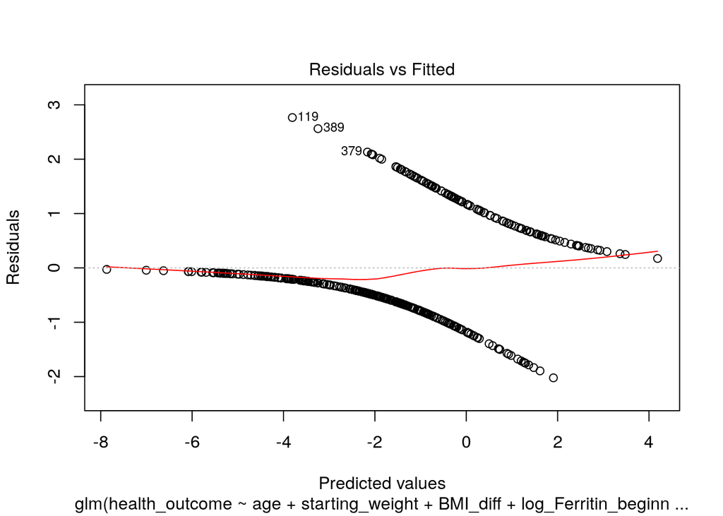

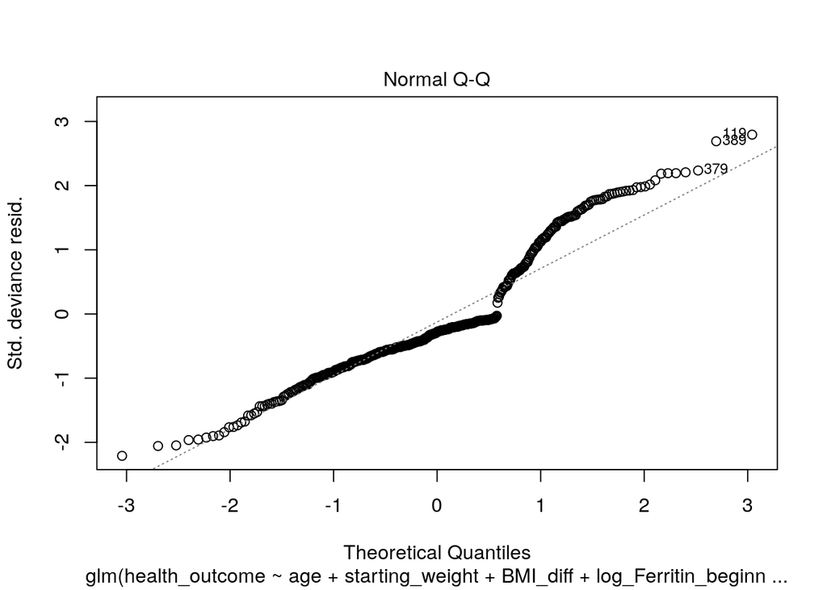

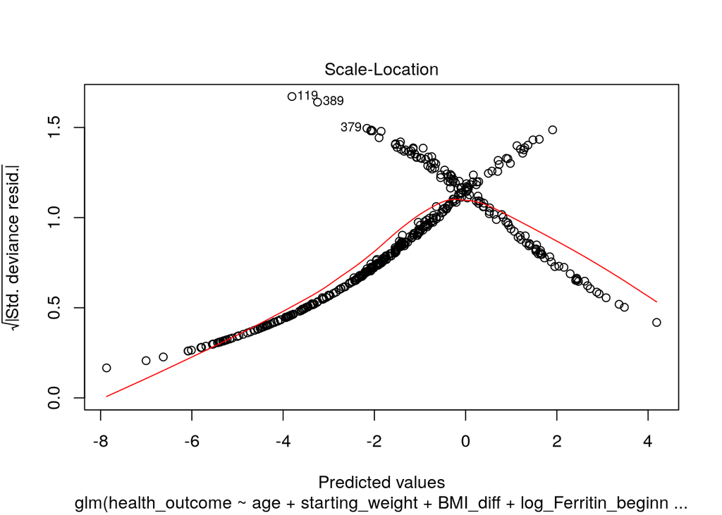

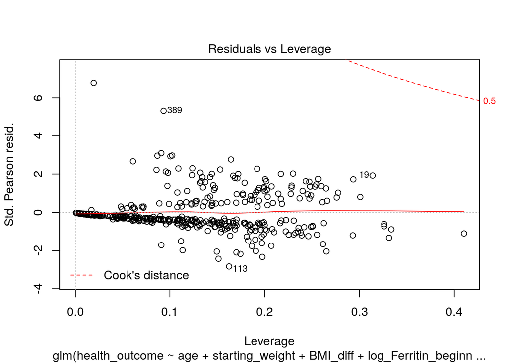

```r
plot(logit_men)
```

```r
vif(logit_men)
```

```
##                            GVIF Df GVIF^(1/(2*Df))
## age                    1.390660  1        1.179263
## starting_weight        1.378434  1        1.174067
## BMI_diff               1.309175  1        1.144192
## log_Ferritin_beginning 1.429164  1        1.195477
## Hb_beginning           1.252659  1        1.119222
## donation_frequency     1.537733  1        1.240054
## health_very_good       3.500705  1        1.871017
## health_excellent       3.888774  1        1.971998
## cholesterol_d          1.282884  1        1.132645
## blood_sugar_d          1.259869  1        1.122439
## HBP_d                  1.231999  1        1.109954
## low_hb_hist_d          1.332168  1        1.154196
## iron_supp_d            1.622751  2        1.128660
## freq_calm_d            1.442880  2        1.095992
## freq_red_meat_d        1.608058  2        1.126096
## freq_fruits_d          1.420022  2        1.091626
## freq_juices_d          1.504778  2        1.107562
## freq_wholem_d          1.366492  2        1.081189
## freq_milk_d            1.608806  2        1.126227
## freq_cof_d             1.521865  2        1.110693
## freq_tea_d             1.546020  2        1.115074
## phys_cond_d            1.782983  2        1.155545
## act_heavy_d            1.790026  2        1.156684
## sleep_enough_d         1.389425  2        1.085697
## day_act_d              1.356657  2        1.079239
## h_act_light_d          1.626458  2        1.129304
## vita_multi_d           1.539843  2        1.113959
## sleep_tired_d          1.512317  2        1.108947
## anti_inf_d             1.529671  2        1.112114
## phys_inf_d             1.875602  2        1.170268
## freq_alc_d             1.375645  2        1.082995
```

```r
logistic.display(logit_men,simplified=TRUE)
```

```
##
##                                  OR   lower95ci   upper95ci     Pr(>|Z|)
## age                       1.0891992  0.96062657   1.2349804 1.824703e-01
## starting_weight           1.1547096  1.03836778   1.2840868 7.935123e-03
## BMI_diff                  0.9214170  0.74162233   1.1448002 4.599301e-01
## log_Ferritin_beginning    0.7100568  0.50917876   0.9901839 4.358040e-02
## Hb_beginning              1.1075411  0.94634662   1.2961924 2.030930e-01
## donation_frequency        0.6819443  0.53680371   0.8663278 1.717689e-03
## health_very_good         19.7843447  7.09617722  55.1593179 1.158484e-08
## health_excellent         77.9902940 23.58571765 257.8885258 9.349275e-13
## cholesterol_dTRUE         0.4590070  0.13951595   1.5101313 1.999936e-01
## blood_sugar_dTRUE         2.6720917  0.38249376  18.6671651 3.216946e-01
## HBP_dTRUE                 1.4681060  0.54087521   3.9849031 4.510450e-01
## low_hb_hist_dTRUE         0.6056830  0.18133268   2.0230875 4.151606e-01
## iron_supp_dStable         1.0742343  0.40392200   2.8569363 8.859065e-01
## iron_supp_dIncreased      2.2001078  0.71401243   6.7792578 1.696631e-01
## freq_calm_dStable         0.9532081  0.49099493   1.8505399 8.874102e-01
## freq_calm_dIncreased      1.3370146  0.56005072   3.1918682 5.129925e-01
## freq_red_meat_dStable     0.7054289  0.35706044   1.3936855 3.151638e-01
## freq_red_meat_dIncreased  0.4562395  0.16981491   1.2257726 1.196483e-01
## freq_fruits_dStable       0.8564508  0.44519528   1.6476096 6.425107e-01
## freq_fruits_dIncreased    0.7924096  0.33703859   1.8630300 5.937206e-01
## freq_juices_dStable       1.7470133  0.87296090   3.4962109 1.149946e-01
## freq_juices_dIncreased    0.8134427  0.35629064   1.8571609 6.239763e-01
## freq_wholem_dStable       0.9545060  0.45983848   1.9813082 9.005575e-01
## freq_wholem_dIncreased    0.9638562  0.41724396   2.2265601 9.313267e-01
## freq_milk_dStable         1.4443969  0.72426989   2.8805317 2.964805e-01
## freq_milk_dIncreased      2.3930304  1.01356903   5.6499304 4.651244e-02
## freq_cof_dStable          1.2126302  0.47596280   3.0894684 6.861804e-01
## freq_cof_dIncreased       1.0407480  0.31048328   3.4886141 9.483987e-01
## freq_tea_dStable          0.5643134  0.28363896   1.1227288 1.030723e-01
## freq_tea_dIncreased       0.6228735  0.23211989   1.6714269 3.472145e-01
## phys_cond_dStable         0.1313616  0.06487369   0.2659916 1.710971e-08
## phys_cond_dIncreased      0.2580815  0.09779846   0.6810543 6.222831e-03
## act_heavy_dStable         0.4505989  0.11886807   1.7081067 2.409936e-01
## act_heavy_dIncreased      0.4890156  0.04446101   5.3785609 5.587218e-01
## sleep_enough_dStable      1.4103213  0.69206716   2.8740074 3.438462e-01
## sleep_enough_dIncreased   1.1637088  0.38217301   3.5434688 7.895719e-01
## day_act_dStable           0.6792122  0.31308992   1.4734719 3.275948e-01
## day_act_dIncreased        0.7722624  0.29111614   2.0486300 6.036337e-01
## h_act_light_dStable       1.0015305  0.46858301   2.1406312 9.968513e-01
## h_act_light_dIncreased    0.7897315  0.31510477   1.9792648 6.145638e-01
## vita_multi_dStable        0.9618831  0.42462195   2.1789244 9.257838e-01
## vita_multi_dIncreased     0.7299344  0.23466647   2.2704747 5.866402e-01
## sleep_tired_dStable       2.5028781  0.99625065   6.2879745 5.094156e-02
## sleep_tired_dIncreased    3.1715717  1.17255811   8.5785659 2.299476e-02
## anti_inf_dStable          0.8859899  0.34816154   2.2546377 7.994896e-01
## anti_inf_dIncreased       1.0614305  0.34023276   3.3113648 9.181996e-01
## phys_inf_dStable          1.7591809  0.44772460   6.9121002 4.185041e-01
## phys_inf_dIncreased      11.5352737  2.20981945  60.2142131 3.726815e-03
## freq_alc_dStable          1.8154860  0.80274419   4.1059024 1.520684e-01
## freq_alc_dIncreased       1.2527622  0.41388584   3.7918984 6.900391e-01
```

```r
tidy_logit_men <-
  logit_men %>%
  tidy %>%
  mutate(OR = exp(estimate),
         group = "Men") %>% mutate(p.value = p.value * 2)
#p-values are multiplied as we analyse the data twice
```

# Bootstraps

https://data.princeton.edu/wws509/r/c3s1

https://stats.stackexchange.com/questions/304833/how-to-calculate-odds-ratio-and-95-confidence-interval-for-logistic-regression

https://www.andrewheiss.com/blog/2016/04/25/convert-logistic-regression-standard-errors-to-odds-ratios-with-r/

```r
detach("package:safeBinaryRegression", unload=TRUE)
#safeBinaryRegression messes up booting
```

## Define auxiliary functions for bootstrapping

```r
# https://www.painblogr.org/2017-10-18-purrring-through-bootstraps.html


get_coefficients <- function(data, boot_ind){
  fit <- glm (health_outcome~.,
              data[boot_ind,],
              family = "binomial")
#  print(names(coef(fit)))
  return(coef(fit))
}



compute_Bca_CI <-function(fit_boot,conf = 0.95){
  cat("compute_Bca_CI with conf: ",conf,"\n")
  Bca_inf = rep(0, length(fit_boot$t0))
  Bca_sup = rep(0, length(fit_boot$t0))
  for (i_regressor in 1:length(fit_boot$t0)){
    CI <- boot.ci(fit_boot, type = "bca", index=i_regressor,conf = conf)
    Bca_inf[i_regressor] <- CI$bca[4]
    Bca_sup[i_regressor] <- CI$bca[5]
  }
  return(tibble(Bca_inf,Bca_sup, regressor = names(fit_boot$t0)) %>%
           filter(regressor != "(Intercept)"))
}


get_bootstrap <- function(data, nb_boot){
 cat(nrow(data),"get_bootstrap 1\n")


    fit_boot <- boot(data, statistic= get_coefficients, R = nb_boot)

 cat(nrow(data),"get_bootstrap 2\n")
  fit_boot_distrib <- as.tibble(fit_boot$t)
  names(fit_boot_distrib) <- names(fit_boot$t0)

  fit_boot_Bca <- compute_Bca_CI(fit_boot)
  fit_boot_Bca_2 <- compute_Bca_CI(fit_boot,conf=0.80)
  cat(nrow(data),"get_bootstrap 3\n")
  return(list(fit_boot_distrib,fit_boot_Bca,fit_boot_Bca_2))
}
```

## Run bootstrapping

```r
# Error in t.star[r, ] <- res[[r]] :
#   number of items to replace is not a multiple of replacement length
#can sometimes be fixed by just adding bootstrap, but sometimes requires dropping out a variable


get_bootstrap_coeffs <- function(regression_data, current_group, nb_boot )
{

  ## preprocess and standardize data

    test_data_std <- regression_data %>%
      filter(group == current_group) %>%
      dplyr::select(donor, age, starting_weight, BMI_diff,
                    log_Ferritin_beginning, Hb_beginning,
                    donation_frequency) %>%
      gather(key = key, value = value, -donor) %>%
      group_by(key) %>%
      mutate(value_scale = scale(value, scale = FALSE)[,1]) %>%
      dplyr::select(-value) %>%
      spread(key = key, value = value_scale)

    if (current_group == "Men") {
      test_data_std <- inner_join(test_data_std,regression_data %>%
                                    dplyr::select(donor, health_outcome, health_very_good, health_excellent,
                                                #  sleep_night_d, ##Error in t.star[r, ] <- res[[r]] :
                                                  cholesterol_d,
                                                  blood_sugar_d,
                                                  HBP_d,
                                                  low_hb_hist_d,
                                                  iron_supp_d,
                                                  freq_calm_d,
                                                  freq_red_meat_d,
                                                  freq_fruits_d,
                                                  freq_juices_d,
                                                  freq_wholem_d,
                                                  freq_milk_d,
                                                  freq_cof_d,
                                                  freq_tea_d,
                                                  phys_cond_d,
                                                  act_heavy_d,
                                                  sleep_enough_d,
                                                  day_act_d,
                                                  h_act_light_d,
                                                  vita_multi_d,
                                                  #vita_iron_d, #Error in t.star[r, ] <- res[[r]]
                                                  sleep_tired_d,
                                                  anti_inf_d,
                                                  phys_inf_d,
                                                  #  ment_inf_d,
                                                  freq_alc_d
                                                #  life_qual, #breaks causality
                                                #  employment #breaks causality
                                                #  education # Error in t.star[r, ] <- res[[r]] :
                                                # smoking_behavior #Error in t.star[r, ] <- res[[r]] :

                                    ),
                                  by = "donor") %>%
        dplyr::select(-donor)
    }

    if (current_group == "Women") {
      test_data_std <- inner_join(test_data_std,regression_data %>%
                                    dplyr::select(donor, health_outcome, health_very_good, health_excellent,
                                                #  sleep_night_d, #Error in t.star[r, ] <- res[[r]] :
                                                  cholesterol_d,
                                                  blood_sugar_d,
                                                  HBP_d,
                                                  low_hb_hist_d,
                                                  iron_supp_d,
                                                  freq_calm_d,
                                                  freq_red_meat_d,
                                                  freq_fruits_d,
                                                  freq_juices_d,
                                                  freq_wholem_d,
                                                  freq_milk_d,
                                                  freq_cof_d,
                                                  freq_tea_d,
                                                  phys_cond_d,
                                                  act_heavy_d,
                                                  sleep_enough_d,
                                                  day_act_d,
                                                  h_act_light_d,
                                                  vita_multi_d,
                                                  #vita_iron_d, #Error in t.star[r, ] <- res[[r]]
                                                  sleep_tired_d,
                                                  anti_inf_d,
                                                  phys_inf_d,
                                                  # ment_inf_d,
                                                  freq_alc_d
                                                 # life_qual, #breaks causality
                                                #  employment #breaks causality
                                                #  education #Error in t.star[r, ] <- res[[r]] :
                                               #   smoking_behavior # Error in t.star[r, ] <- res[[r]] :

                                    ),
                                  by = "donor") %>%
        dplyr::select(-donor)
    }

  cat(nrow(test_data_std),current_group,"get_bootstrap_coeffs 1\n")
  result <- test_data_std %>%
  get_bootstrap(nb_boot = nb_boot)

  cat(nrow(test_data_std),current_group,"get_bootstrap_coeffs 2\n")
  bootstrap_distrib <- result[[1]] %>%
    gather(key = regressor, value = coefficient) %>%
    filter(regressor != "(Intercept)") %>%
    mutate(group = current_group)
      cat(nrow(test_data_std),current_group,"get_bootstrap_coeffs 3\n")
  Bca_CI  <- result[[2]] %>% mutate(group = current_group)
  Bca_CI_2  <- result[[3]] %>% mutate(group = current_group)
  cat(nrow(test_data_std),current_group,"get_bootstrap_coeffs 4\n")
  return(list(bootstrap_distrib,Bca_CI,Bca_CI_2))
}




#get_from_file_ferr = TRUE



set.seed(125)

for(group_str in c("Women","Men")){
  output_file_distrib = paste0("../results/bootstraps/exp_coeff_boot_distrib_seed_125_ctr_strata_final_",group_str,".rdata")
  output_file_Bca = paste0("../results/bootstraps/exp_coeff_boot_Bca_seed_125_ctr_strata_final_",group_str,".rdata")
  output_file_Bca_2 = paste0("../results/bootstraps/exp_coeff_boot_Bca_2_seed_125_ctr_strata_final_",group_str,".rdata")
  get_from_file_ferr <- all(file.exists(output_file_distrib),file.exists(output_file_Bca),file.exists(output_file_Bca_2) )
  if (get_from_file_ferr){
    cat("Loading boots from file for group ",group_str,"\n")
    stuff <- list()
    load(file=output_file_distrib)
    load(file=output_file_Bca)
    load(file=output_file_Bca_2)
    stuff[[1]] <- temp1
    stuff[[2]] <- temp2
    stuff[[3]] <- temp3
  }else {
    stuff <- get_bootstrap_coeffs(regression_data, group_str, nb_boot = 10000)
    #         stuff <- get_bootstrap_coeffs(regression_data, group_str, nb_boot = 1000)
    temp1 <- stuff[[1]]
    temp2 <- stuff[[2]]
    temp3 <- stuff[[3]]
    save(temp1,file=output_file_distrib)
    save(temp2,file=output_file_Bca)
    save(temp3,file=output_file_Bca_2)
  }

  if(!exists("bootstrap_distrib")){
    cat("initializing bootstrap_distrib, bootstrap_Bca_CI_2 & bootstrap_Bca_CI\n")

    bootstrap_distrib <- stuff[[1]]
    cat("nrow(bootstrap_distrib)",nrow(bootstrap_distrib),"\n")
    bootstrap_Bca_CI <- stuff[[2]]
    cat("nrow(bootstrap_Bca_CI)",nrow(bootstrap_Bca_CI),"\n")
    bootstrap_Bca_CI_2 <- stuff[[3]]
    cat("nrow(bootstrap_Bca_CI_2)",nrow(bootstrap_Bca_CI_2),"\n")
  }else
  {
    cat("bootstrap_distrib & bootstrap_Bca_CI already exist\n")
    bootstrap_distrib<-bind_rows(bootstrap_distrib, stuff[[1]])
    bootstrap_Bca_CI<-bind_rows(bootstrap_Bca_CI, stuff[[2]])
    bootstrap_Bca_CI_2<-bind_rows(bootstrap_Bca_CI_2, stuff[[3]])
  }

}
```

```
## Loading boots from file for group  Women
## initializing bootstrap_distrib, bootstrap_Bca_CI_2 & bootstrap_Bca_CI
## nrow(bootstrap_distrib) 500000
## nrow(bootstrap_Bca_CI) 50
## nrow(bootstrap_Bca_CI_2) 50
## Loading boots from file for group  Men
## bootstrap_distrib & bootstrap_Bca_CI already exist
```

```r
bootstrap_Bca_CI %>%  group_by(group) %>% count()
```

```
## # A tibble: 2 x 2
## # Groups:   group [2]
##   group     n
##   <chr> <int>
## 1 Men      50
## 2 Women    50
```

# Forest plots

```r
# "\U0394 BMI"

regressor_values <- c(
 "age" = "Age",
   "BMI_diff" = "BMI difference",
   "donation_frequency" = "Donation frequency",
   "Hb_beginning" = "Initial Hemoglobin",
   "log_Ferritin_beginning" ="Initial Ferritin",
   "starting_weight" ="Initial weight",
   "health_very_good" ="Initial health rating \n Very good vs Satisfactory/Good",
    "health_excellent" = "Initial health rating \n Excellent vs Satisfactory/Good",


 "cholesterol_dTRUE" = "Elevated cholesterol detected",
"blood_sugar_dTRUE" = "Elevated blood sugar detected",
"HBP_dTRUE" = "High blood pressure detected",
"low_hb_hist_dTRUE" = "Low haemoglobin detected",
"iron_supp_dStable" = "FRCBS iron supplementation stable",
"iron_supp_dIncreased" = "FRCBS iron supplementation increased",
"vita_multi_dStable" = "Frequency multivitamine stable",
"vita_multi_dIncreased" = "Frequency multivitamine increased",
#"vita_iron_dStable" = "Frequency iron supplements stable",
#"vita_iron_dIncreased" = "Frequency iron supplements increased",
"anti_inf_dStable" = "Frequency of anti-inflammatory stable",
"anti_inf_dIncreased" = "Frequency of anti-inflammatory increased",
"freq_red_meat_dStable" = "Frequency of red meat stable",
"freq_red_meat_dIncreased" = "Frequency of red meat increased",
"freq_fruits_dStable" = "Frequency of fruits stable",
"freq_fruits_dIncreased" = "Frequency of fruits increased",
"freq_juices_dStable" = "Frequency of juices stable",
"freq_juices_dIncreased" = "Frequency of juices increased",
"freq_wholem_dStable" = "Frequency of whole milk stable",
"freq_wholem_dIncreased" = "Frequency of whole milk increased",
"freq_milk_dStable" = "Frequency of milk stable",
"freq_milk_dIncreased" = "Frequency of milk increased",
"freq_cof_dStable" = "Frequency of coffee stable",
"freq_cof_dIncreased"  = "Frequency of coffee increased",
"freq_tea_dStable" = "Frequency of tea stable",
"freq_tea_dIncreased" = "Frequency of tea increased",
"freq_alc_dStable" = "Frequency of alcohol stable",
"freq_alc_dIncreased" = "Frequency of alcohol increased",
"phys_inf_dStable" = "Physical symptoms inferred stable",
"phys_inf_dIncreased" = "Physical symptoms interfered increased",
"phys_cond_dStable" = "Physical condition stable",
"phys_cond_dIncreased" = "Physical condition increased",
"act_heavy_dStable" = "Ability for heavy activity stable",
"act_heavy_dIncreased" = "Ability for heavy activity increased",
"day_act_dStable"  = "Typical day activity stable",
"day_act_dIncreased" = "Typical day activity increased",
"h_act_light_dStable"  = "Hours for light activity stable",
"h_act_light_dIncreased"  = "Hours for light activity increased",
"sleep_enough_dStable" = "Enough sleep stable",
"sleep_enough_dIncreased"  = "Enough sleep increased",
"sleep_tired_dStable" = "Tired during day stable",
"sleep_tired_dIncreased" = "Tired during day increased",
"freq_calm_dStable" = "Frequency of feeling calm stable",
"freq_calm_dIncreased" =  "Frequency of feeling calm increase"
#"life_qualgood" = "Quality of life good",
#"life_qualvery_good" = "Quality of life very good",
#"employmentTRUE" = "Full time employed"
)
```

```r
temp <-
  tidy_logit_men %>%
  bind_rows(tidy_logit_women) %>%
  dplyr::select(group, term, OR, p.value) %>%
  rename(regressor = term) %>%
  inner_join(bootstrap_Bca_CI,
             by =  c("regressor", "group")) %>%
  filter(regressor != "(Intercept)") %>%
  mutate(Bca_inf = exp(Bca_inf),
         Bca_sup = exp(Bca_sup),
         is_sig = p.value < 0.05) %>%
  mutate(
    regressor = plyr::revalue(regressor, regressor_values),
    regressor = ordered(regressor,
                        levels =  as.character(regressor_values)),
    regressor = fct_rev(regressor),
    # group = case_when(group == "Women" ~ "Pre-menopausal women",
    #                   group == "Post_menopause_women" ~ "Post-menopausal women",
    #                   TRUE ~ "Men"),
    group = ordered(group, levels = c(  "Women", "Men"  )
    )
  )

temp2 <-
  tidy_logit_men %>%
  bind_rows(tidy_logit_women) %>%
  dplyr::select(group, term, OR, p.value) %>%
  rename(regressor = term) %>%
  inner_join(bootstrap_Bca_CI_2,
             by =  c("regressor", "group")) %>%
  filter(regressor != "(Intercept)") %>%
  mutate(Bca_inf = exp(Bca_inf),
         Bca_sup = exp(Bca_sup),
         is_sig = p.value < 0.05) %>%
  mutate(
    regressor = plyr::revalue(regressor, regressor_values),
    regressor = ordered(regressor,
                        levels =  as.character(regressor_values)),
    regressor = fct_rev(regressor),
    # group = case_when(group == "Pre_menopause_women" ~ "Pre-menopausal women",
    #                   group == "Post_menopause_women" ~ "Post-menopausal women",
    #                   TRUE ~ "Men"),
    group = ordered(group, levels = c(  "Women", "Men"  )
    )
  )
```

```r
bootstrap_Bca_CI <- temp
plotdata <- bootstrap_distrib %>%
  mutate(regressor = plyr::revalue(regressor, regressor_values),
  regressor = ordered(regressor,
                  levels = as.character(regressor_values)),
  regressor = fct_rev(regressor),
  # group = case_when(group == "Pre_menopause_women" ~ "Pre-menopausal women",
  #   group == "Post_menopause_women" ~ "Post-menopausal women",
  #   TRUE ~ "Men"),
  group = ordered(group, levels = c( "Men",  "Women" ) )) %>%
  mutate(OR = exp(coefficient))

bootstrap_Bca_CI_2 <- temp2

file <- "../results/exp_bootstrap_Bca_CI.csv"
temp <- bootstrap_Bca_CI %>% mutate_if(is.numeric, round, digits = 3) %>% dplyr::select(regressor,group,p.value,OR,Bca_inf,Bca_sup) %>% arrange(desc(regressor),group)
write.csv(temp ,file = file,row.names = FALSE)
```

# Small plot of filtered variables for main paper

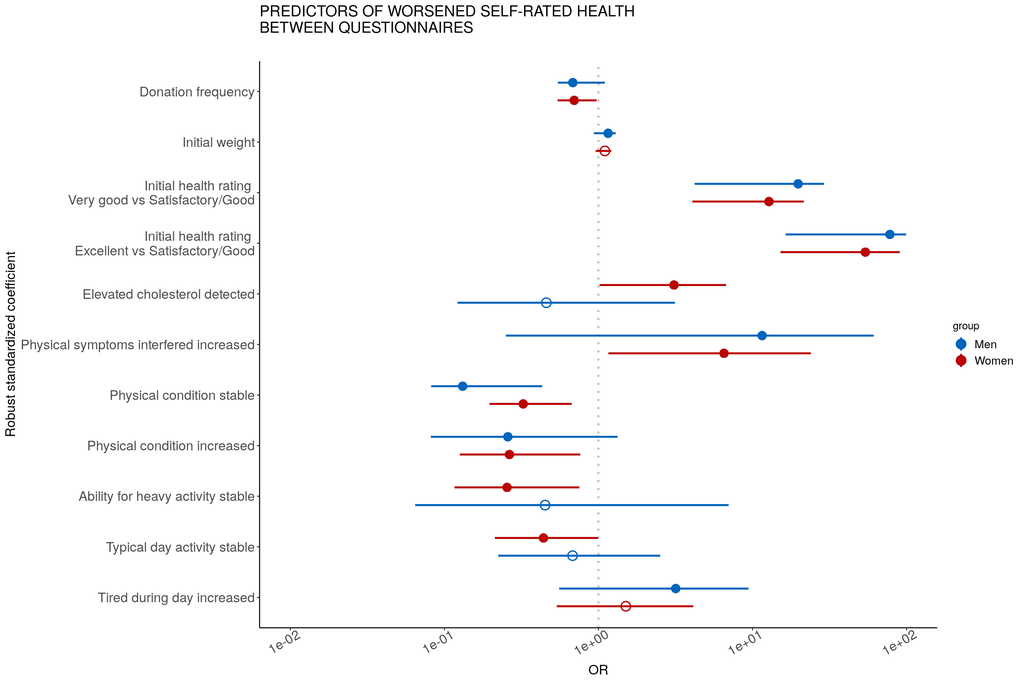

```r
#set the forest plot OR scale lims
orlimR <- 100
orlimL <- 1/orlimR
pointrange2size <- 1.4
#Filter for those that are sig in some:
bootstrap_Bca_CI_filtered <- bootstrap_Bca_CI %>% group_by(regressor) %>% mutate(some_sig= any(is_sig)) %>% filter(some_sig == TRUE)
#Set values on axes limits to facilitate plotting
bootstrap_Bca_CI_filtered$Bca_sup[bootstrap_Bca_CI_filtered$Bca_sup > orlimR] <- orlimR
bootstrap_Bca_CI_filtered$Bca_sup[bootstrap_Bca_CI_filtered$Bca_sup == 0] <- orlimR
bootstrap_Bca_CI_filtered$Bca_inf[bootstrap_Bca_CI_filtered$Bca_inf < orlimL] <- orlimL

#Filter for those that are sig in some:
bootstrap_Bca_CI_filtered_2 <- bootstrap_Bca_CI_2 %>% group_by(regressor) %>% mutate(some_sig= any(is_sig)) %>% filter(some_sig == TRUE)
#Set values on axes limits to facilitate plotting
bootstrap_Bca_CI_filtered_2$Bca_sup[bootstrap_Bca_CI_filtered_2$Bca_sup > orlimR] <- orlimR
bootstrap_Bca_CI_filtered_2$Bca_sup[bootstrap_Bca_CI_filtered_2$Bca_sup == 0] <- orlimR
bootstrap_Bca_CI_filtered_2$Bca_inf[bootstrap_Bca_CI_filtered_2$Bca_inf < orlimL] <- orlimL


plotdata_filtered <- plotdata %>% filter(plotdata$regressor %in% bootstrap_Bca_CI_filtered$regressor)


p  <- ggplot(aes(x = regressor, y = OR, color = group, fill = group),data = plotdata_filtered) +
  geom_hline(yintercept = 1 , color = "grey", linetype = "dotted",
             size = 1) +
  # geom_violin(alpha = 0.15, trim = TRUE, position = position_dodge(width = 0.8), size = 0.1) +
  geom_pointrange(data = bootstrap_Bca_CI_filtered,
                  aes(ymin=Bca_inf, ymax = Bca_sup, shape = is_sig, color = group, fill = group),
                  position = position_dodge(width = 0.7), size = 1, linetype = 1) +
  # geom_pointrange(data = bootstrap_Bca_CI_filtered_2,
  #                 aes(ymin=Bca_inf, ymax = Bca_sup, shape = is_sig, color = group, fill = group),
  #                 position = position_dodge(width = 0.7), size = pointrange2size) +
  # # geom_point(data = bootstrap_Bca_CI,
  #            aes(shape = is_sig, fill = group),
  #            position = position_dodge(width = 0.8), size = 2) +
    scale_color_manual(values = c(  "#0065BD", "#BA0303" ),
                     limits = c("Men",  "Women" )) +
     scale_fill_manual(values = c(  "#0065BD", "#BA0303" ),
                     limits = c("Men",  "Women" )) +
 scale_shape_manual(values = c(1,16)) +
  scale_y_log10(limits=c(orlimL,orlimR)) +
  # scale_x_discrete(labels=parse(text=unique(bootstrap_Bca_CI$regressor)))
  # ylim(1/35, 35) +
  guides(shape = FALSE) +
  theme_classic() +
  # theme(legend.position = c(0.8,0.9),
  #       legend.title = element_blank(),
  #       legend.box = "vertical",
  #       legend.text = element_text(size = 20),
  #       plot.title =  element_text(size = 24,
  #                                 hjust = 0),
  #       panel.grid.minor.y = element_blank(),
  #       axis.line = element_line(colour="black"),
  #       axis.title.y = element_blank(),
  #       axis.title.x = element_text(size = 24),
  #       axis.text = element_text(size = 22),
  #       panel.grid.major.y = element_blank()) +
  coord_flip() +
  xlab("Robust standardized coefficient") +
  labs(title = "PREDICTORS OF WORSENED SELF-RATED HEALTH \nBETWEEN QUESTIONNAIRES",
       subtitle = "") +
   theme(axis.title = element_text(size = 14),
        strip.text =  element_text(size = 14),
        legend.text = element_text(size = 12),
        strip.background = element_rect(fill = "white"),
        strip.background.x = element_blank(),
        axis.text.y = element_text(size = 14),
        axis.text.x = element_text(size = 14, angle = 30,hjust = 0.8),
        plot.title =  element_text(size = 16),
        plot.subtitle = element_text(size = 16,
                                     hjust = 0.5))

p
```

```r
p <- p +   labs(title = NULL,subtitle = NULL)
ggplot2::ggsave(filename = "../results/figures/exp_small_log_reg_results_b.pdf",
                plot= p,
# do not change these rather just scale the ready pdf later if you need.
       width = 35,
       height = 25,
       dpi = 600,
       units = "cm")
```

# Big plot of all variables for supplement

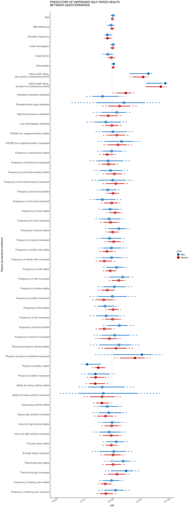

```r
bootstrap_Bca_CI$Bca_sup[bootstrap_Bca_CI$Bca_sup > orlimR] <- orlimR
bootstrap_Bca_CI$Bca_sup[bootstrap_Bca_CI$Bca_sup == 0] <- orlimR
bootstrap_Bca_CI$Bca_inf[bootstrap_Bca_CI$Bca_inf < orlimL] <- orlimL

#Set values on axes limits to facilitate plotting
bootstrap_Bca_CI_2$Bca_sup[bootstrap_Bca_CI_2$Bca_sup > orlimR] <- orlimR
bootstrap_Bca_CI_2$Bca_sup[bootstrap_Bca_CI_2$Bca_sup == 0] <- orlimR
bootstrap_Bca_CI_2$Bca_inf[bootstrap_Bca_CI_2$Bca_inf < orlimL] <- orlimL


p2  <- ggplot(aes(x = regressor, y = OR, color = group, fill = group),data = plotdata) +
  geom_hline(yintercept = 1 , color = "grey", linetype = "dotted",
             size = 1) +
  # geom_violin(alpha = 0.15, trim = TRUE, position = position_dodge(width = 0.8), size = 0.1) +
  geom_pointrange(data = bootstrap_Bca_CI,
                  aes(ymin=Bca_inf, ymax = Bca_sup, shape = is_sig, color = group, fill = group),
                  position = position_dodge(width = 0.7), size = 1, linetype = 2) +
  geom_pointrange(data = bootstrap_Bca_CI_2,
                  aes(ymin=Bca_inf, ymax = Bca_sup, shape = is_sig, color = group, fill = group),
                  position = position_dodge(width = 0.7), size = pointrange2size) +
  # # geom_point(data = bootstrap_Bca_CI,
  #            aes(shape = is_sig, fill = group),
  #            position = position_dodge(width = 0.8), size = 2) +
    scale_color_manual(values = c(  "#0065BD", "#BA0303" ),
                     limits = c("Men",  "Women" )) +
     scale_fill_manual(values = c(  "#0065BD", "#BA0303" ),
                     limits = c("Men",  "Women" )) +
 scale_shape_manual(values = c(1,16)) +
  scale_y_log10(limits=c(orlimL,orlimR)) +
  # scale_x_discrete(labels=parse(text=unique(bootstrap_Bca_CI$regressor)))
  # ylim(1/35, 35) +
  guides(shape = FALSE) +
  theme_classic() +
  # theme(legend.position = c(0.8,0.9),
  #       legend.title = element_blank(),
  #       legend.box = "vertical",
  #       legend.text = element_text(size = 20),
  #       plot.title =  element_text(size = 24,
  #                                 hjust = 0),
  #       panel.grid.minor.y = element_blank(),
  #       axis.line = element_line(colour="black"),
  #       axis.title.y = element_blank(),
  #       axis.title.x = element_text(size = 24),
  #       axis.text = element_text(size = 22),
  #       panel.grid.major.y = element_blank()) +
  coord_flip() +
  xlab("Robust standardized coefficient") +
  labs(title = "PREDICTORS OF WORSENED SELF-RATED HEALTH \nBETWEEN QUESTIONNAIRES",
       subtitle = "") +
   theme(axis.title = element_text(size = 14),
        strip.text =  element_text(size = 14),
        legend.text = element_text(size = 12),
        strip.background = element_rect(fill = "white"),
        strip.background.x = element_blank(),
        axis.text.y = element_text(size = 14),
        axis.text.x = element_text(size = 14, angle = 30,hjust = 0.8),
        plot.title =  element_text(size = 16),
        plot.subtitle = element_text(size = 16,
                                     hjust = 0.5))

p2
```

```r
p2 <- p2 +   labs(title = NULL,subtitle = NULL)
ggplot2::ggsave(filename = "../results/figures/exp_big_log_reg_results_b.pdf",
                plot= p2,
       width = 35,
       height = 55,
       dpi = 600,
       units = "cm")
```

# Separate plots for individual variables

```r
fig.width=15
fig.height=13
#Load questionnaire data
load(file = "../data/final_data.rdata")
final_data <- data
final_data$group <- as.character(final_data$group)
final_data$group[final_data$group == "Post_menopause_women"] <- "Women"
final_data$group[final_data$group == "Pre_menopause_women"] <- "Women"
final_data$group <- as.factor(final_data$group)
```

## Change in physical condition color

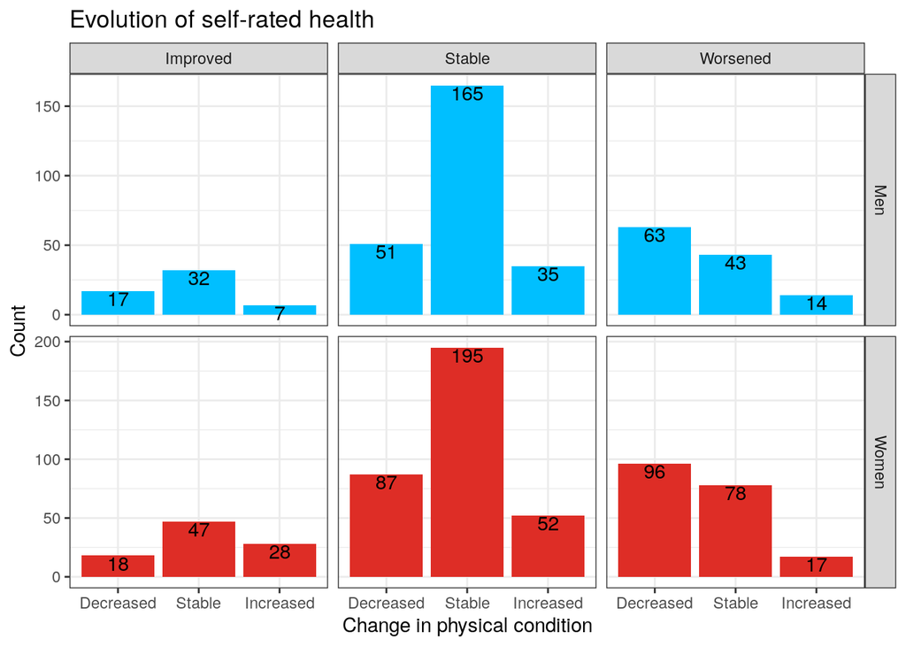

```r
pdata <- final_data %>%
  dplyr::select(donor, group, health, questionnaire) %>%
  drop_na(group) %>%
  filter( group != "Women_pre_menop_no_mens") %>%
  spread(key = questionnaire, value = health) %>%
  filter(First != "NA" & Second != "NA") %>%
  mutate(Difference = case_when(First < Second ~ "Improved",
                                First == Second ~ "Stable",
                                TRUE ~ "Worsened")) %>%
  inner_join(regression_data, by = c("donor", "group")) %>%
  mutate( group = ordered(group, levels = c(  "Men", "Women") ))

p <- ggplot(aes(x= phys_cond_d , fill = group), data=pdata) +
  # geom_hline(yintercept = 15, color = "red", linetype = 3)
  geom_bar()+
  #geom_boxplot(outlier.alpha = 0) +
  #geom_beeswarm(alpha = 0.5, shape = 1) +
  # scale_y_log10() +
  facet_grid(group ~ Difference,scales="free_y") +
  scale_fill_manual(values = c( "#de2d26","#00BFFF" ),
                    limits = c( "Women","Men" )) +
  theme_bw() +
  theme(legend.position = "none") +
  ggtitle("Evolution of self-rated health") +
  xlab("Change in physical condition") +
  ylab("Count") +
  geom_text(stat='count', aes(label=..count..),color="black", vjust=1)
#scale_y_log10()



ggplot2::ggsave(plot=p,filename = "../results/figures/exp_phys_cond_c.pdf",
       width = fig.width,
       height = fig.height,
       dpi = 600,
       units = "cm")

p
```